# Assignment 2

Author

Kevin Linares

Published

September 25, 2024

You may work in pairs or individually for this assignment. Make sure you join a group in Canvas if you are working in pairs. Turn in this assignment as an HTML or PDF file to ELMS. Make sure to include the R Markdown or Quarto file that was used to generate it.

```r
library(tidyverse)
library(gtrendsR)
library(censusapi)
library(ggthemes)
library(knitr)
library(tidyverse)

# set a standard graphic theme for plots from the ggthemes package
theme_set(theme_hc())

options(scipen=999)
```

In this assignment, you will pull from APIs to get data from various data sources and use your data wrangling skills to use them all together. You should turn in a report in PDF or HTML format that addresses all of the questions in this assignment, and describes the data that you pulled and analyzed. You do not need to include full introduction and conclusion sections like a full report, but you should make sure to answer the questions in paragraph form, and include all relevant tables and graphics.

Whenever possible, use piping and `dplyr`. Avoid hard-coding any numbers within the report as much as possible.

## Pulling from APIs

Our first data source is the Google Trends API. Suppose we are interested in the search trends for `crime` and `loans` in Illinois in the year 2020. We could find this using the following code:

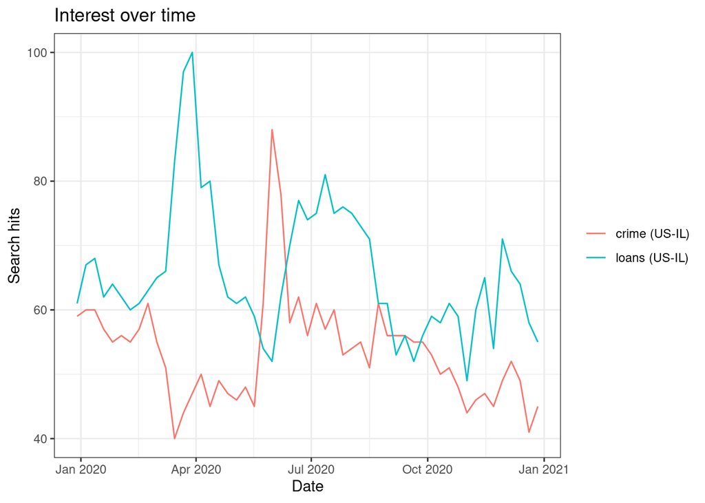

```r
res <- gtrends(c("crime", "loans"),
               geo = "US-IL",
               time = "2020-01-01 2020-12-31",
               low_search_volume = TRUE)

plot(res)
```

Answer the following questions for the keywords “crime” and “loans”.

- Find the mean, median and variance of the search hits for the keywords.

  ```r
  res$interest_over_time |>
    group_by(keyword) |>
     # summary statistics
    summarise(across(hits, list(mean, median, var))) |>
    # rename outputs
    rename(mean_hits=2, median_hits=3, var_hits=4)
  ```

  ```
  # A tibble: 2 × 4
    keyword mean_hits median_hits var_hits
    <chr>       <dbl>       <int>    <dbl>
  1 crime        53.6          54     68.5
  2 loans        65.7          62    110.
  ```

- Which cities (locations) have the highest search frequency for `loans`? Note that there might be multiple rows for each city if there were hits for both “crime” and “loans” in that city. It might be easier to answer this question if we had the search hits info for both search terms in two separate variables. That is, each row would represent a unique city.
  - The following 6 cities below had the highest search frequency for *loans* during our query time period.

  ```r
  res$interest_by_city |>
    filter(keyword == "loans") |>
    arrange(desc(hits)) |>
    select(location, keyword, hits) |>
    head(6)
  ```

  ```
            location keyword hits
  1        Long Lake   loans  100
  2         Rosemont   loans   69
  3        Coal City   loans   68
  4     Ford Heights   loans   67
  5 East Saint Louis   loans   67
  6          Peotone   loans   64
  ```

- Is there a relationship between the search intensities between the two keywords we used?
  - Based on the timeseries plot above, it does not seem that crime and loans are tracking together across time, and therefore may not be associated. However, in April 2020 during the beginning of the pandemic, it appears that people in Illinois were searching more for loans, and searching less for crime.

Repeat the above for keywords related to covid. Make sure you use multiple keywords like we did above. Try several different combinations and think carefully about words that might make sense within this context.

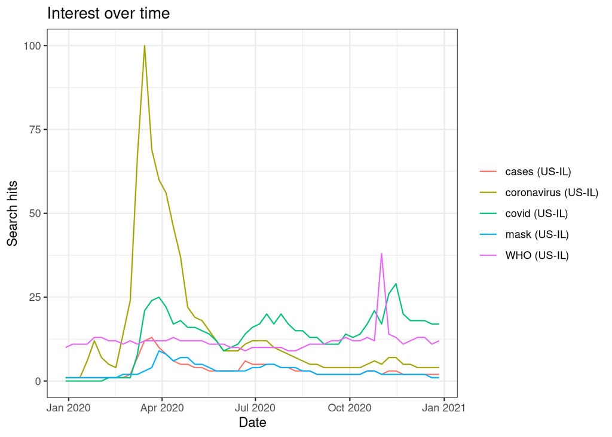

```r
covid <- gtrends(c("covid", "coronavirus", "WHO",
                   #"flu", "pandemic", "SARS",
                   # "vaccine", "PPE
                   # "corona", "sanitizer", "covid-19".
                   "cases", "mask"),
               geo = "US-IL",
               time = "2020-01-01 2020-12-31",
               low_search_volume = TRUE)

plot(covid)
```

## Google Trends + ACS

Now lets add another data set. The `censusapi` package provides a nice R interface for communicating with this API. However, before running queries we need an access key. This (easy) process can be completed here:

https://api.census.gov/data/key_signup.html

Once you have an access key, save it as a text file, then read this key in the `cs_key` object. We will use this object in all following API queries. Note that I called my text file `census-key.txt` – yours might be different!

```r
cs_key <- read_file(
  "~/UMD/classes/fund_comp_data_display_SURV727/assignments/census-key.txt")
```

In the following, we request basic socio-demographic information (population, median age, median household income, income per capita) for cities and villages in the state of Illinois. Documentation for the 5-year ACS API can be found here: https://www.census.gov/data/developers/data-sets/acs-5year.html. The information about the variables used here can be found here: https://api.census.gov/data/2022/acs/acs5/variables.html.

```r
acs_il <- getCensus(name = "acs/acs5",
                    vintage = 2020,
                    vars = c("NAME",
                             "B01001_001E",
                             "B06002_001E",
                             "B19013_001E",
                             "B19301_001E"),
                    region = "place:*",
                    regionin = "state:17",
                    key = cs_key)
head(acs_il)
```

```
  state place                        NAME B01001_001E B06002_001E B19013_001E
1    17 15261 Coatsburg village, Illinois         180        35.6       55714
2    17 15300    Cobden village, Illinois        1018        44.2       38750
3    17 15352      Coffeen city, Illinois         640        33.4       35781
4    17 15378   Colchester city, Illinois        1347        42.2       43942
5    17 15469    Coleta village, Illinois         230        27.7       56875
6    17 15495    Colfax village, Illinois        1088        32.5       58889
  B19301_001E
1       27821
2       19979
3       26697
4       24095
5       23749
6       24861
```

Convert values that represent missing to NAs.

```r
acs_il[acs_il == -666666666] <- NA
```

Now, it might be useful to rename the socio-demographic variables (`B01001_001E` etc.) in our data set and assign more meaningful names.

```r
acs_il <-
  acs_il %>%
  rename(pop = B01001_001E,
         age = B06002_001E,
         hh_income = B19013_001E,
         income = B19301_001E) |>
  as_tibble()
```

It seems like we could try to use this location information listed above to merge this data set with the Google Trends data. However, we first have to clean `NAME` so that it has the same structure as `location` in the search interest by city data. Add a new variable `location` to the ACS data that only includes city names.

```r
acs_il <- acs_il |>
  mutate (location = str_extract(NAME, "[^,]+"),
        location = str_remove(location, "village|city|\\stown|CDP"),
        location = str_trim(location))

acs_covid <-
  covid$interest_by_city |> as_tibble() |>
  mutate(location = str_replace(location, "Saint\\s", "St. "),
         location = str_replace(location, "Sainte\\s", "Ste. "),
         location = str_remove(location, "Fort ") ) |>
  # join with ACS
  left_join(acs_il, relationship = "many-to-many")

glimpse(acs_covid)
```

```
Rows: 1,006
Columns: 12
$ location  <chr> "Bartelso", "Geneva", "Evergreen Park", "Winnetka", "Beckeme…
$ hits      <int> 100, 99, 94, 93, 93, 92, 92, 90, 89, 89, 88, 88, 88, 88, 86,…
$ keyword   <chr> "covid", "covid", "covid", "covid", "covid", "covid", "covid…
$ geo       <chr> "US-IL", "US-IL", "US-IL", "US-IL", "US-IL", "US-IL", "US-IL…
$ gprop     <chr> "web", "web", "web", "web", "web", "web", "web", "web", "web…
$ state     <chr> "17", "17", "17", "17", "17", "17", "17", "17", "17", "17", …
$ place     <chr> "04000", "28872", "24634", "82530", "04533", "82075", "09531…
$ NAME      <chr> "Bartelso village, Illinois", "Geneva city, Illinois", "Ever…
$ pop       <dbl> 789, 21843, 19290, 12361, 1054, 27114, 1401, 906, 29596, 812…
$ age       <dbl> 48.2, 40.4, 41.1, 42.1, 44.3, 46.5, 57.1, 42.8, 47.2, 41.6, …
$ hh_income <dbl> 82361, 116083, 79396, 250001, 51719, 161765, 95556, 36250, 1…
$ income    <dbl> 42470, 52697, 35328, 134596, 23015, 96523, 51748, 30137, 901…
```

Answer the following questions with the “crime” and “loans” Google trends data and the ACS data.

```r
asc_crime_loans <- res$interest_by_city |> as_tibble() |>
  as_tibble() |>
  mutate(location = str_replace(location, "Saint\\s", "St. "),
         location = str_replace(location, "Sainte\\s", "Ste. "),
         location = str_remove(location, "Fort ") ) |>
  # join with ACS
  left_join(acs_il, relationship = "many-to-many")

# unmatched cities
asc_crime_loans |>
  filter(is.na(NAME)) |>
  select(location) |>
  kable()
```

| location |
| --- |
| DePue |
| Plato Center |
| Fenton |
| Walsh |
| Berwick |
| Ancona |
| Ledbetter |

```r
asc_crime_loans |>
  mutate(hh_income_median =
           ifelse(hh_income > mean(hh_income, na.rm=TRUE),
                  "Higher", "Lower")) |>
  filter(!is.na(hh_income_median)) |>
  group_by(hh_income_median, keyword) |>
  reframe(mean_hits = mean(hits, na.rm=TRUE)) |>
  pivot_wider(names_from = keyword, values_from = mean_hits)
```

```
# A tibble: 2 × 3
  hh_income_median crime loans
  <chr>            <dbl> <dbl>
1 Higher            64.1  56.3
2 Lower             68.4  56.1
```

- Is there a relationship between the median household income and the search popularity of the Google trends terms? Describe the relationship and use a scatterplot with `qplot()`.
  - At a glance, it does not appear that there is a linear relationship between median household income and search popularity. However, when we color code by search terms crime and loans, we begin to see that as median household income increases, the popularity in crime searches decreases, and to some extant same for the search term loans.

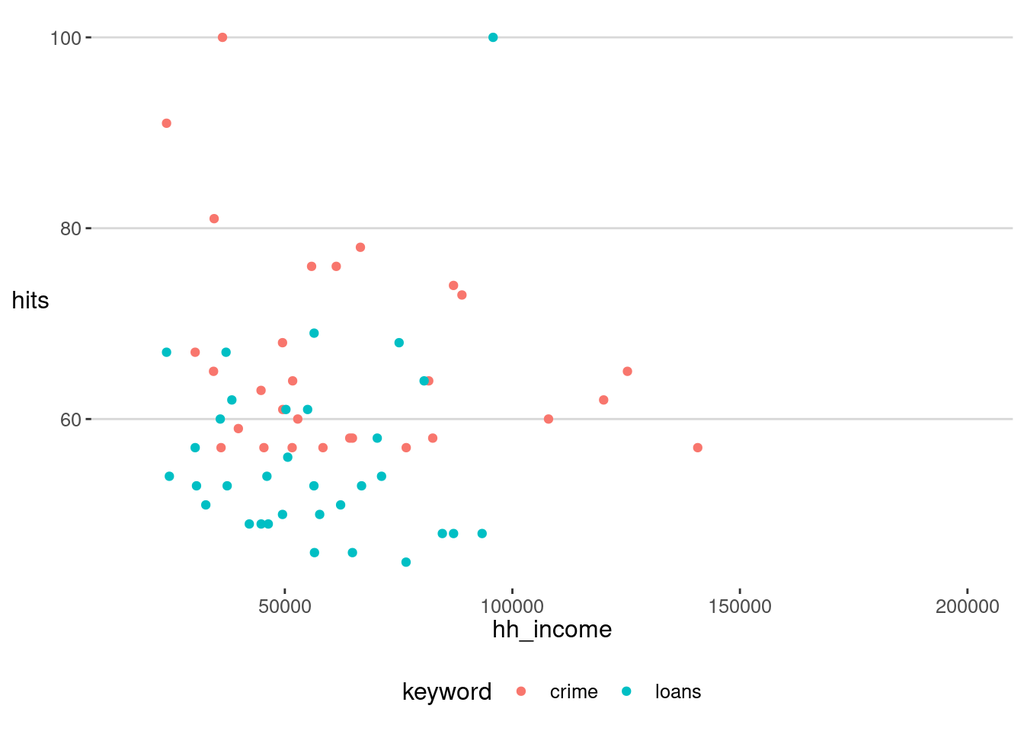

```r
asc_crime_loans |>
  ggplot(aes(x=hh_income, y=hits, color=keyword)) +
  geom_point()
```

Repeat the above steps using the covid data and the ACS data.

```r
acs_covid |>
  filter(is.na(NAME)) |>
  select(location) |>
  kable()
```

| location |
| --- |
| Plato Center |
| Village of Lakewood |
| Graymont |
| Ancona |
| Camanche |
| DePue |
| Ste. Genevieve |
| Village of Lakewood |
| Plato Center |
| Louisiana |
| New Harmony |
| DePue |
| Plato Center |
| Bloomsdale |
| Rosamond |
| Louisiana |
| Barnhill |
| Massbach |
| Gulf Port |
| Fenton |
| Village of Lakewood |
| Graymont |
| Berwick |
| Rosamond |
| Shullsburg |

```r
acs_covid |>
  mutate(hh_income_median =
           ifelse(hh_income > mean(hh_income, na.rm=TRUE),
                  "Higher", "Lower")) |>
  filter(!is.na(hh_income_median)) |>
  group_by(hh_income_median, keyword) |>
  reframe(mean_hits = mean(hits, na.rm=TRUE)) |>
  pivot_wider(names_from = keyword, values_from = mean_hits)
```

```
# A tibble: 2 × 6
  hh_income_median   WHO cases coronavirus covid  mask
  <chr>            <dbl> <dbl>       <dbl> <dbl> <dbl>
1 Higher            76.2  78.5        75.6  81.3  72.7
2 Lower             75.7  75.6        77.1  80.3  74.4
```

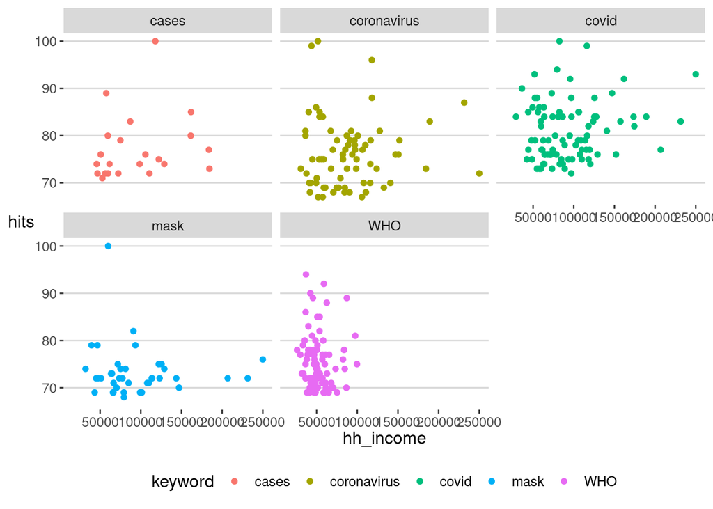

```r
acs_covid |>
  ggplot(aes(x=hh_income, y=hits, color=keyword)) +
  geom_point() +
  facet_wrap(~keyword)
```